# Linear Regression using Seaborn

### Author: mcswe | https://github.com/mcswe

```python
import seaborn as sns
import numpy as py
import matplotlib.pyplot as plt
import pandas as pd
from sklearn import datasets, linear_model
from sklearn.model_selection import train_test_split
from sklearn.metrics import mean_squared_error
from sklearn.preprocessing import PolynomialFeatures
```

Today I will build a machine learning model that uses Seaborn's `mpg` dataset to effectively and accurately predict the miles per gallon column, using data from other columns.

First, I will import the `mpg` dataset from Seaborn, drop non-numerical columns: `origin` and `name`, and then drop any `NaN`'s that may exist.

```python
mpg = sns.load_dataset("mpg")
mpg = mpg.drop(columns = ['origin', 'name'])
mpg = mpg.dropna()
```

Now I will split my `mpg` data into train, validation, and test sets of 250, 75, and 67 respectively. I will drop the `mpg` column (our target variable) for my `X` sets, and keep only the `mpg` column for my `y` sets.

```python
ds = train_test_split(mpg, test_size = 67, random_state=1)

# splits entire df into 67 test and 325 remaining. DO NOT TOUCH!!!
y_test = ds[1]['mpg']
X_test = ds[1].drop(columns='mpg')

ds2 = train_test_split(ds[0], test_size = 250, random_state=1)
# splits the 325 remaining ('train') into 250 train and 142 val
y_val = ds2[0]['mpg']
X_val = ds2[0].drop(columns='mpg')

y_train = ds2[1]['mpg']
X_train = ds2[1].drop(columns='mpg')
```

Now I want to train a successful linear regression model to predict the mpg column. I will make use of several functions to do so:

- sklearn `linear_model.LinearRegression()` initializes a Linear Regression object.
- `predict()` predict mpg values based off training and validation data
- `score` computes the coefficient of determination
- `mean_squared_error` computes the mean squared error (i.e. mean squared deviation)

```python
model = linear_model.LinearRegression()
```

```python
model_fit = model.fit(X_train,y_train)

y_train_pred = model.predict(X_train)
y_val_pred = model.predict(X_val)

codet_train = model.score(X_train, y_train)
mse_train = mean_squared_error(y_train, y_train_pred, squared=False)

codet_val = model.score(X_val, y_val)
mse_val = mean_squared_error(y_val, y_val_pred, squared=False)
```

```python
print("Coefficient of Determination - Training Set: " + str(codet_train))
print("Mean Squared Error - Training Set: " + str(mse_train))
print("Coefficient of Determination - Validation Set: " + str(codet_val))
print("Mean Squared Error - Validation Set: " + str(mse_val))
```

```
Coefficient of Determination - Training Set: 0.8125691533358554
Mean Squared Error - Training Set: 3.3613282485561453
Coefficient of Determination - Validation Set: 0.7909660793921055
Mean Squared Error - Validation Set: 3.520378930857902
```

We can see that the mean squared error of our training and validation set aren't the best. We want this value as close to 0 as possible. Additionally, we want the coefficient of determination as close to 1 as possible.

To help the model perform even better, I will perform **feature expansion** on the `mpg` dataset. I will make use of `PolynomialFeatures` which is part of the `sklearn.preprocessing.PolynomialFeatures` class. This generates a dataframe consisting of all polynomial combinations of features with a degree less than or equal to a specified degree (in this case, a degree of 2).

In doing so, I will fit this data to a new linear regression model, as well as compute new coefficients of determination and mean squared errors of the new data.

```python
poly = PolynomialFeatures(2, interaction_only=True)
```

```python
poly_xtrain = pd.DataFrame(poly.fit_transform(X_train))
poly_xval = pd.DataFrame(poly.fit_transform(X_val))
```

```python
polymodel = linear_model.LinearRegression()
model2_fit = polymodel.fit(poly_xtrain, y_train)
```

```python
y_train_poly_pred = polymodel.predict(poly_xtrain)
y_val_poly_pred = polymodel.predict(poly_xval)

polymodel.score(poly_xtrain, y_train)
mean_squared_error(y_train, polymodel.predict(poly_xtrain), squared=False)
polymodel.score(poly_xval, y_val)
mean_squared_error(y_val, polymodel.predict(poly_xval), squared=False)

print("Coefficient of Determination - Training Set: " + str(polymodel.score(poly_xtrain, y_train)))
print("Mean Squared Error - Training Set: " + str(mean_squared_error(y_train, polymodel.predict(poly_xtrain), squared=False)))
print("Coefficient of Determination - Validation Set: " + str(polymodel.score(poly_xval, y_val)))
print("Mean Squared Error - Validation Set: " + str(mean_squared_error(y_val, polymodel.predict(poly_xval), squared=False)))
```

```
Coefficient of Determination - Training Set: 0.8888916723929823
Mean Squared Error - Training Set: 2.5879965745113283
Coefficient of Determination - Validation Set: 0.8229229251262815
Mean Squared Error - Validation Set: 3.2401282423031263
```

For clarity and to prevent you from having to scroll up to compare CoD and MSE values, I will display the coefficients of determination and mean squared errors of both the original dataset and the expanded dataset together:

```python
print("------------ ORIGINAL DATASET ------------")
print("Coefficient of Determination - Training Set: " + str(codet_train))
print("Mean Squared Error - Training Set: " + str(mse_train))
print("Coefficient of Determination - Validation Set: " + str(codet_val))
print("Mean Squared Error - Validation Set: " + str(mse_val))
print("\n")
print("------------ EXPANDED DATASET ------------")
print("Coefficient of Determination - Training Set: " + str(polymodel.score(poly_xtrain, y_train)))
print("Mean Squared Error - Training Set: " + str(mean_squared_error(y_train, polymodel.predict(poly_xtrain), squared=False)))
print("Coefficient of Determination - Validation Set: " + str(polymodel.score(poly_xval, y_val)))
print("Mean Squared Error - Validation Set: " + str(mean_squared_error(y_val, polymodel.predict(poly_xval), squared=False)))
```

```
------------ ORIGINAL DATASET ------------
Coefficient of Determination - Training Set: 0.8125691533358554
Mean Squared Error - Training Set: 3.3613282485561453
Coefficient of Determination - Validation Set: 0.7909660793921055
Mean Squared Error - Validation Set: 3.520378930857902


------------ EXPANDED DATASET ------------
Coefficient of Determination - Training Set: 0.8888916723929823
Mean Squared Error - Training Set: 2.5879965745113283
Coefficient of Determination - Validation Set: 0.8229229251262815
Mean Squared Error - Validation Set: 3.2401282423031263
```

We can see the coefficients of determination got closer to 1.0 and the mean squared error got closer to 0.0 *after* we expanded the feature values in the original dataset. This tells us that our polynomial expansion did exactly what we wanted: it made our model predict values with more accuracy.

### Validation

Now I will perform some "sanity checks" to help validate my model.

```python
results = pd.DataFrame({"Actual": y_val, "Predicted": y_val_poly_pred})
```

1. **Calculate the residuals**

   We can see a slightly Gaussian distribution of the residuals, and the mean is close to 0. Specifically, the model predicted higher mpg values for about half the data points and lower mpg values for the other half of datapoints. This shows the model performed well and made no shocking predictions.

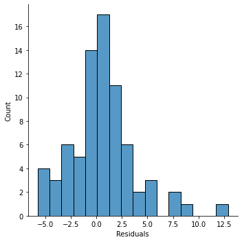

```python
results["Residuals"] = results["Actual"] - results["Predicted"]
sns.displot(data = results, x = "Residuals");
```

1. **Predictions vs the ground-truth ("actual") values**

   We can see a linear relationship between our predicted mpg values and the actual mpg values. This indicates predictions were close or exact to actual mpg values. Some outliers (noise) exist which indicates potential underfitting but this does not deter from the strong linear shape of the datapoints.

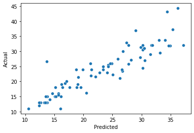

```python
sns.scatterplot(data = results, x = "Predicted", y = "Actual")
```

1. **Homoscedasticity**

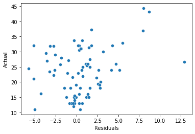

```python
sns.scatterplot(data = results, x = "Residuals", y = "Actual")
```

1. **Model Coefficients**

   The coefficients of determination applied to each feature vector gives us a directly interpretable signal about what features the model found useful. In the bar plot below, we can see that cylinders and acceleration had the most influence on the model's mpg predictions.

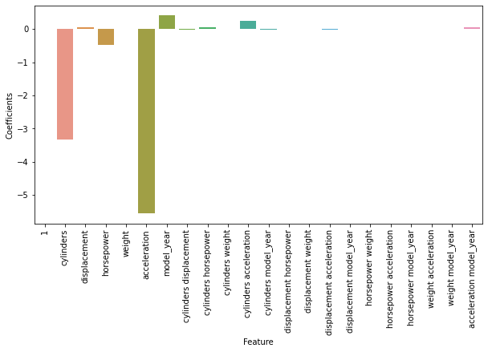

```python
coefplot = model2_fit.coef_
mc = pd.DataFrame({"Feature": poly.get_feature_names(X_train.columns), "Coefficients": coefplot})
poly.get_feature_names(mpg.columns)
fig, ax = plt.subplots(figsize=(10, 5))
plt.xticks(rotation=90)
sns.barplot(data=mc, x = "Feature", y = "Coefficients", ax=ax)
```

### Evaluating on the Test Set

Model accuracy on the test set was similar to the validation set! Its closeness in coefficient of determination and mean squared error values indicate the model went predicted expected and nearly-accurate mpg values.

```python
print("------------ EXPANDED DATASET ------------")
print("Coefficient of Determination - Training Set: " + str(polymodel.score(poly_xtrain, y_train)))
print("Mean Squared Error - Training Set: " + str(mean_squared_error(y_train, polymodel.predict(poly_xtrain), squared=False)))
print("Coefficient of Determination - Validation Set: " + str(polymodel.score(poly_xval, y_val)))
print("Mean Squared Error - Validation Set: " + str(mean_squared_error(y_val, polymodel.predict(poly_xval), squared=False)))
print("\n")
print("------------ TEST SET ------------")
poly_xtest = pd.DataFrame(poly.fit_transform(X_test))
print("Coefficient of Determination - Training Set: " + str(polymodel.score(poly_xtest, y_test)))
print("Mean Squared Error - Training Set: " + str(mean_squared_error(y_test, polymodel.predict(poly_xtest), squared=False)))
```

```
------------ EXPANDED DATASET ------------
Coefficient of Determination - Training Set: 0.8888916723929823
Mean Squared Error - Training Set: 2.5879965745113283
Coefficient of Determination - Validation Set: 0.8229229251262815
Mean Squared Error - Validation Set: 3.2401282423031263


------------ TEST SET ------------
Coefficient of Determination - Training Set: 0.8407353785808424
Mean Squared Error - Training Set: 3.1894561460010564
```